# Lista 5 - Capítulos 4 e 5

Gustavo Tironi

2023-06-01

# 1 Setando um tema padrão

Primeiramente, gostaria de destacar que irei apresentar os gráficos já modificados, pois não velo sentido em demonstrá-los idênticos ao livro. Então, primeiramente irei definir um tema global, cujo será aplicado em todos os gráficos, caso não seja indicado o contrário.

```r
theme_set(theme_classic())
theme_update(legend.position="top")
theme_update(plot.title = element_text(size = 12, face = "bold"))
```

# 2 Gráficos do capítulo 4

Aqui, não irei me alongar muito nas explicações, e focarei masi em apresentar os gráficos, pontuando apenas o que eu achar relevante.

Inicialmente, para evitar a repetição de **labs** desnecessários, resolvi alterar o nome das variáveis mais frequentes dos *databases*, para assim, os rotulos dos eixos aparecerem de forma correta, sem necessidade de usar o label. Para isso, user o comando **rename** do *dplyr*.

```r
gapminder <- gapminder::gapminder %>% rename("Ano" = "year",
 "País" = "country",
 "Continente" = "continent",
 "População" = "pop",
 "PIBpercapita" = "gdpPercap",
 "Expvida" = "lifeExp")

gss_sm <- socviz::gss_sm %>%
rename("Ano" = "year",
 "Idade" = "age",
 "Crianças" = "childs",
 "Região" = "bigregion",
 "Religião" = "religion")

organdata <- socviz::organdata %>%
rename("Ano" = "year",
 "País" = "country",
 "Doadores" = "donors",
 "População" = "pop",
 "Estradas" = "roads")

midwest <- ggplot2::midwest %>%
rename("Estado" = "state",
 "Área" = "area")
```

Com isso feito, começarei a apesentar os gráficos construídos

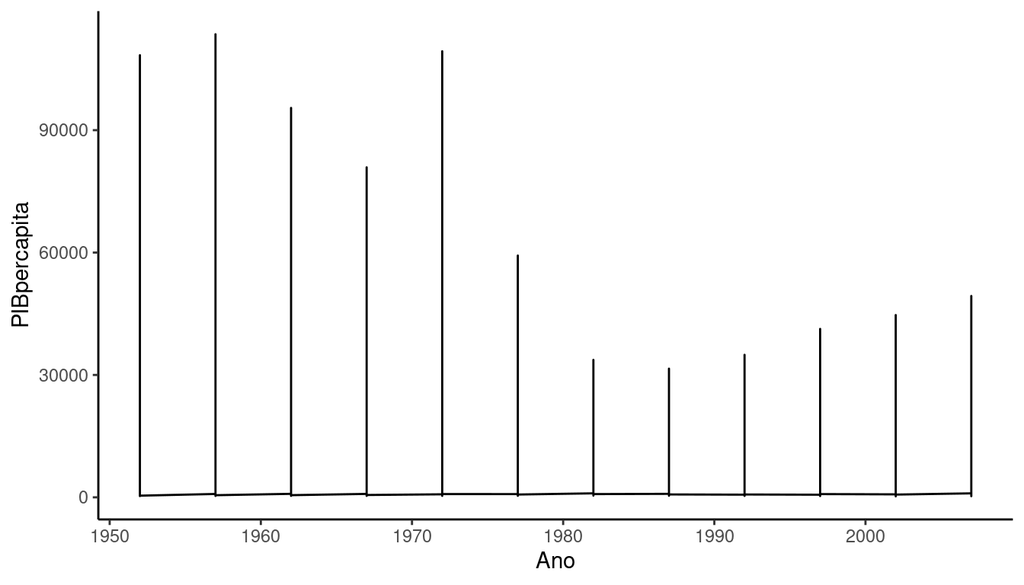

```r
ggplot(gapminder, mapping = aes(x = Ano, y = PIBpercapita)) +
geom_line()
```

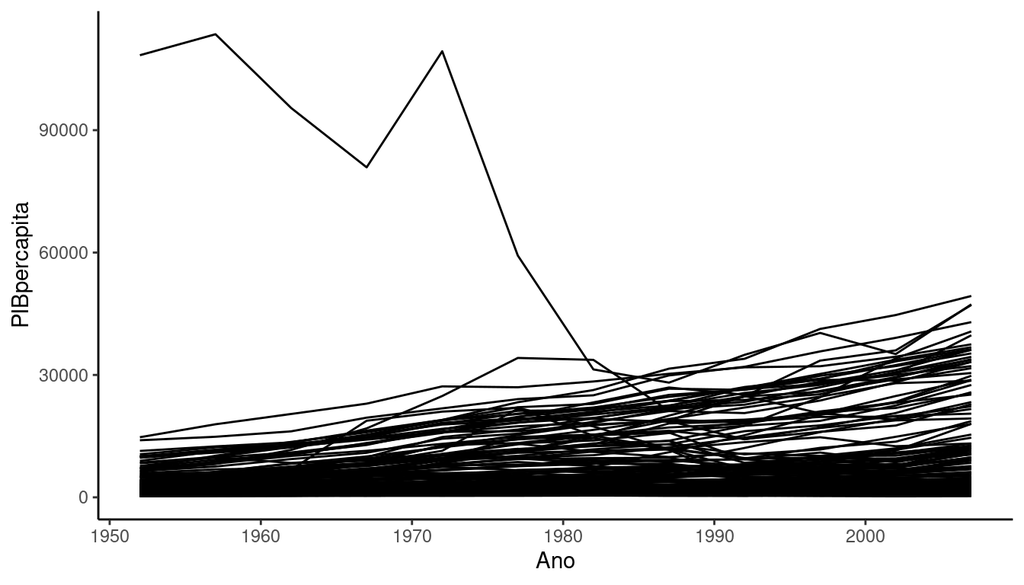

```r
ggplot(gapminder, mapping = aes(x = Ano, y = PIBpercapita)) +
geom_line(aes(group=País))
```

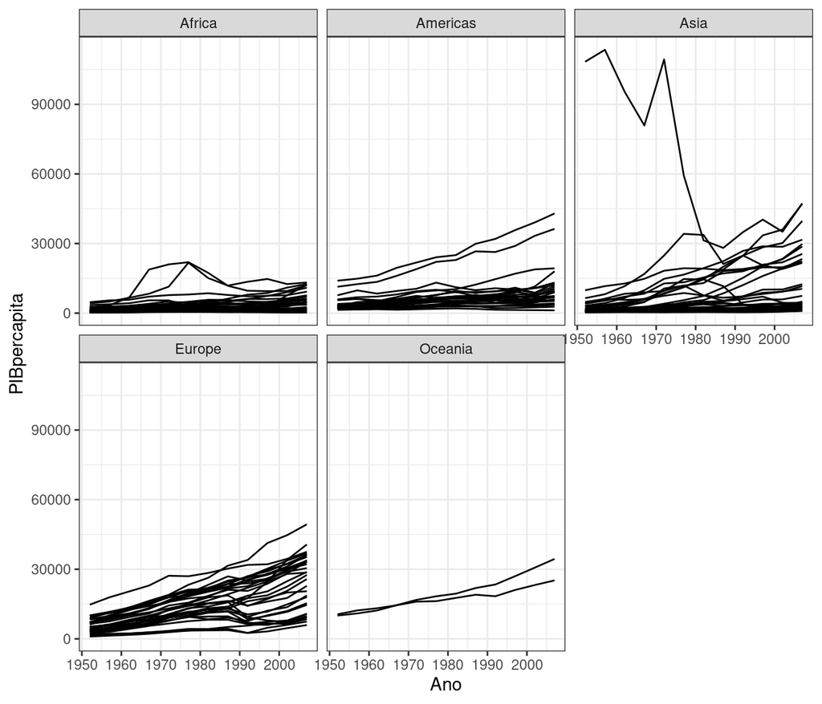

```r
ggplot(gapminder, mapping = aes(x = Ano, y = PIBpercapita)) +
geom_line(aes(group=País)) +
facet_wrap(~Continente) +
theme_bw()
```

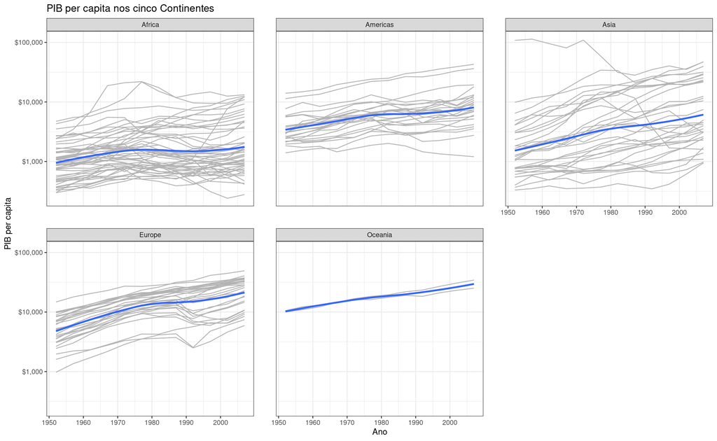

```r
ggplot(gapminder, mapping = aes(x = Ano, y = PIBpercapita)) +
geom_line(color = "gray70", aes(group=País)) +
geom_smooth(size=1.1, method="loess", se=FALSE) +
scale_y_log10(labels=scales::dollar) +
facet_wrap(~ Continente, ncol=3) +
labs(x = "Ano",
     y = "PIB per capita",
     title = "PIB per capita nos cinco Continentes") +
theme_bw() +
theme(panel.spacing = unit(2, "lines"))
```

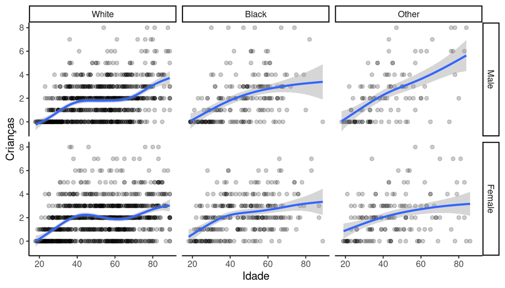

```r
ggplot(data = gss_sm, mapping = aes(x = Idade, y = Crianças)) +
geom_point(alpha=0.2) +
geom_smooth() +
facet_grid(sex~race)
```

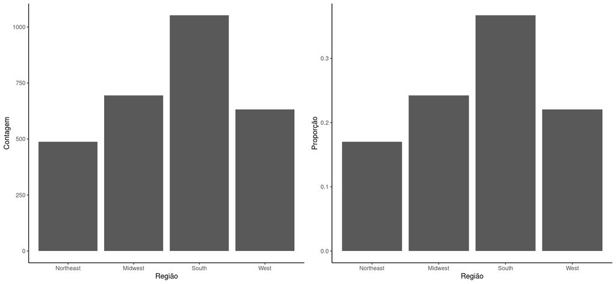

```r
p1 <- ggplot(data = gss_sm, mapping = aes(x = Região)) +
geom_bar() +
labs(y = "Contagem")

p2 <- ggplot(data = gss_sm, mapping = aes(x = Região)) +
geom_bar(mapping = aes(y=after_stat(prop), group = 1)) +
labs(y = "Proporção")

grid.arrange(p1, p2,
             ncol=2, nrow=1)
```

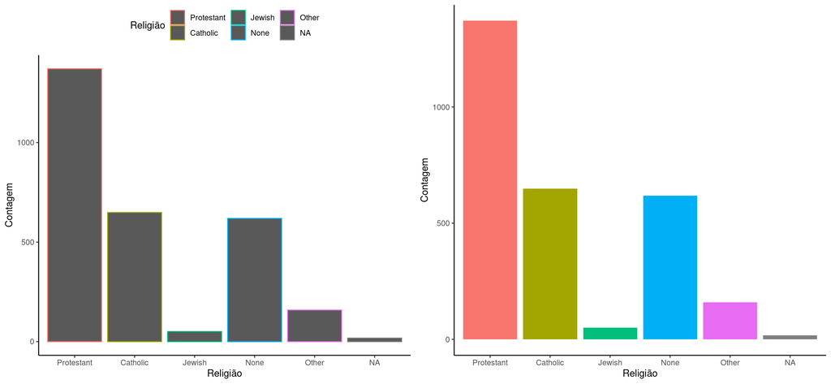

```r
p1 <- ggplot(data = gss_sm, aes(x = Religião, color = Religião)) +
geom_bar()  +
theme() +
labs(y = "Contagem")

p2 <- ggplot(data = gss_sm, mapping = aes(x = Religião, fill = Religião)) +
geom_bar() +
guides(fill = FALSE) +
labs(y = "Contagem")

grid.arrange(p1, p2,
             ncol=2, nrow=1)
```

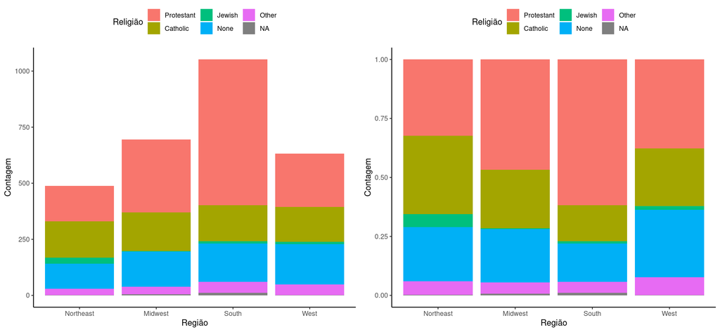

```r
p1 <- ggplot(data = gss_sm, mapping = aes(x = Região, fill = Religião)) +
geom_bar() +
theme() +
labs(y = "Contagem")

p2 <- ggplot(data = gss_sm, mapping = aes(x = Região, fill = Religião)) +
geom_bar(position = "fill") +
theme() +
labs(y = "Contagem")

grid.arrange(p1, p2,
             ncol=2, nrow=1)
```

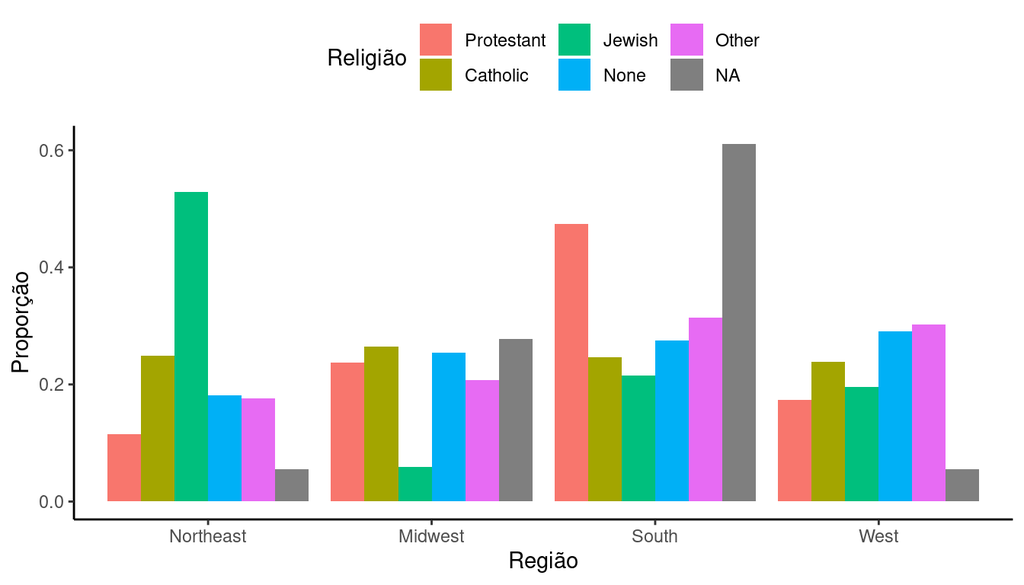

```r
ggplot(data = gss_sm, mapping = aes(x = Região, fill = Religião)) +
geom_bar(position = "dodge", aes(y = after_stat(prop), group = Religião)) +
labs(y = "Proporção")
```

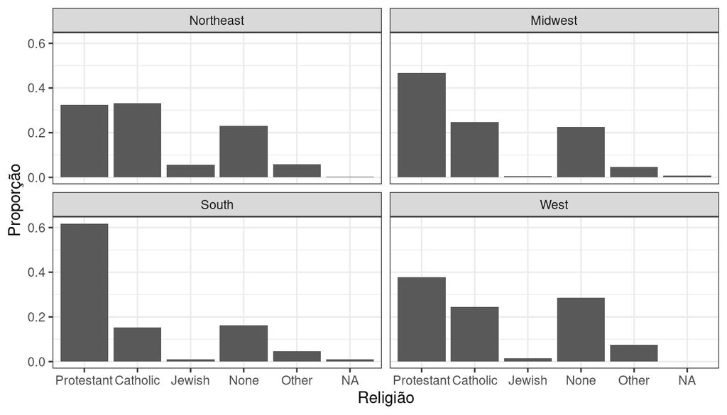

```r
ggplot(data = gss_sm, mapping = aes(x = Religião)) +
geom_bar(position = "dodge", aes(y = after_stat(prop), group = Região)) +
facet_wrap(~Região, ncol = 2) +
theme_bw() +
labs(y = "Proporção")
```

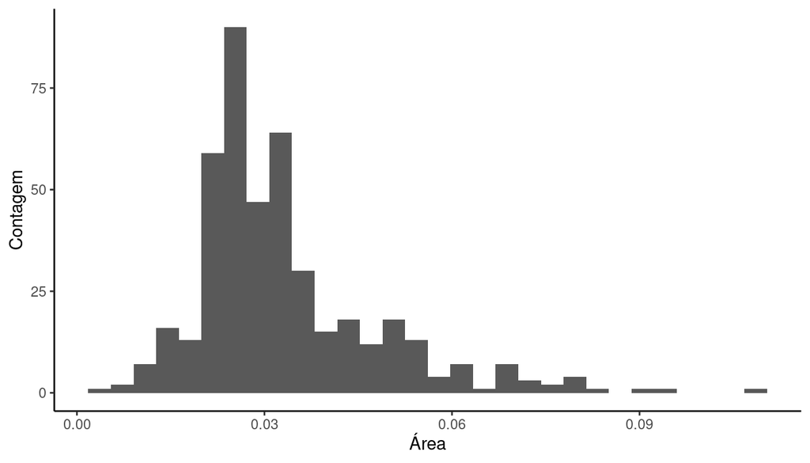

```r
ggplot(data = midwest, mapping = aes(x = Área)) +
geom_histogram() +
labs(y = "Contagem")
```

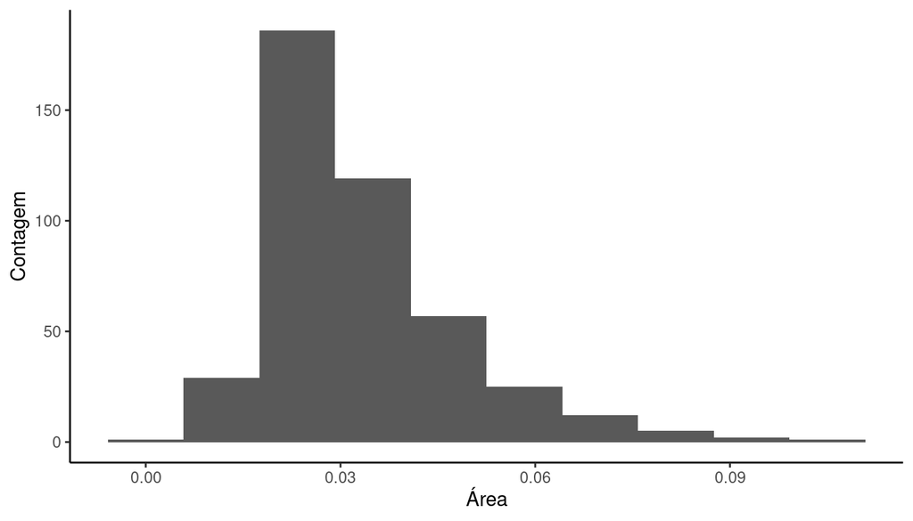

```r
ggplot(data = midwest, mapping = aes(x = Área)) +
geom_histogram(bins = 10) +
labs(y = "Contagem")
```

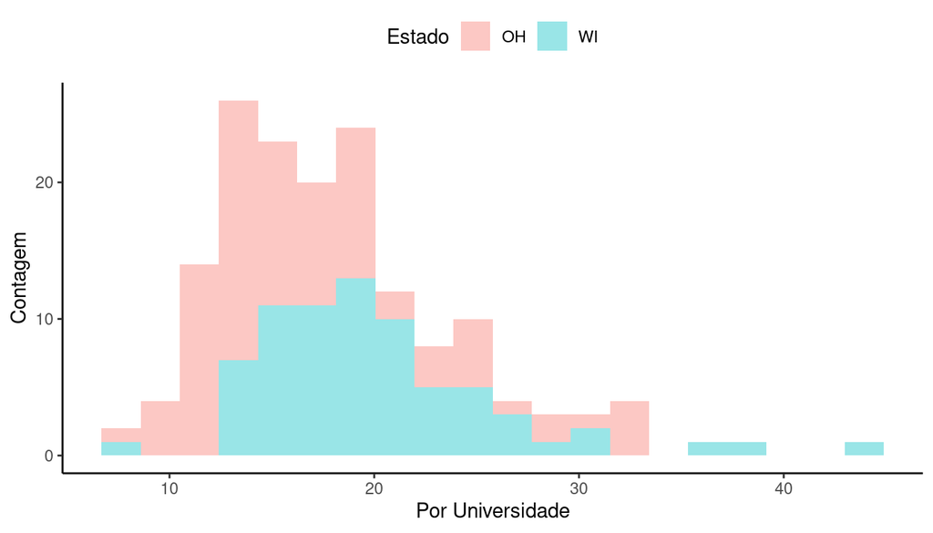

```r
oh_wi <- c("OH", "WI")

ggplot(data = subset(midwest, Estado %in% oh_wi), mapping = aes(x = percollege, fill = Estado)) +
geom_histogram(bins = 20, alpha = 0.4)  +
labs(y = "Contagem", x = "Por Universidade")
```

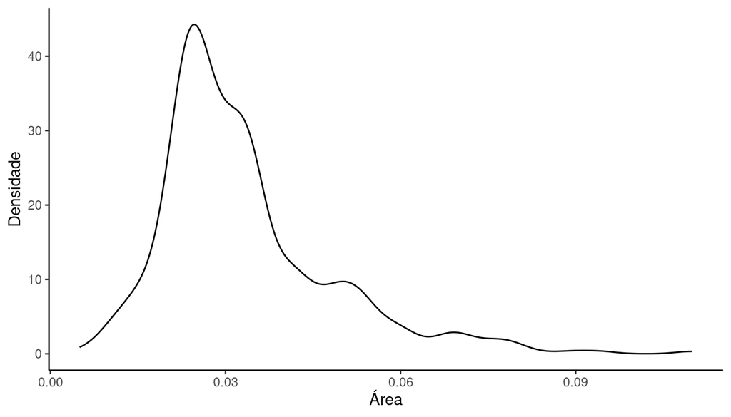

```r
ggplot(data = midwest,  mapping = aes(x = Área)) +
geom_density() +
labs(y = "Densidade")
```

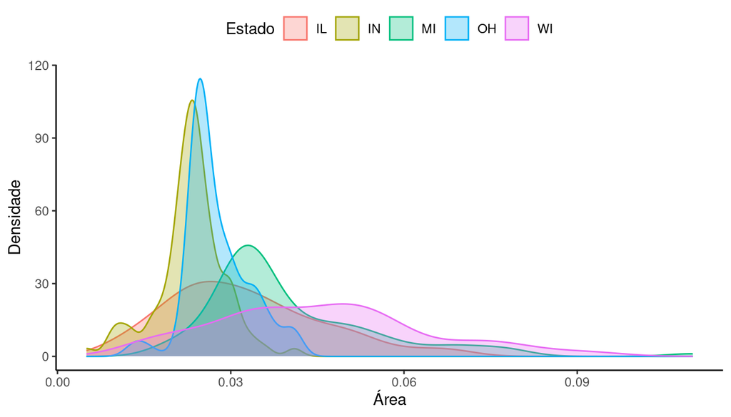

```r
ggplot(data = midwest,  mapping = aes(x = Área, fill = Estado, color = Estado)) +
geom_density(alpha = 0.3) +
labs(y = "Densidade")
```

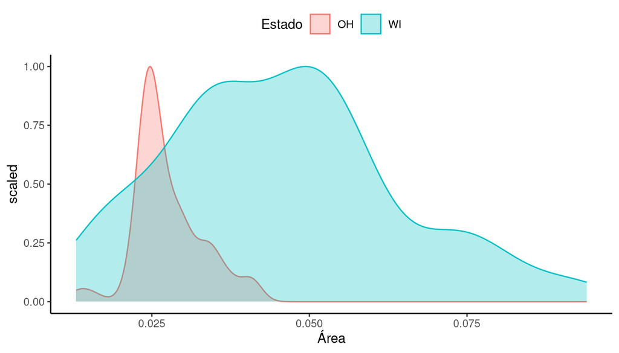

```r
ggplot(data = subset(midwest, Estado %in% oh_wi), mapping = aes(x = Área, fill = Estado, color = Estado)) +
geom_density(alpha = 0.3, mapping = aes(y = after_stat(scaled)))
```

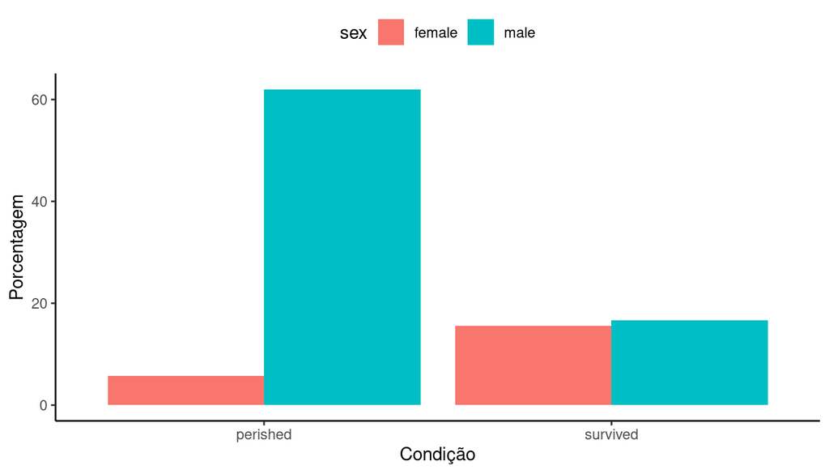

```r
ggplot(data = titanic, mapping = aes(x = fate, y = percent, fill = sex)) +
geom_bar(position = "dodge", stat = "identity") +
labs(y = "Porcentagem", x = "Condição", color = "Sexo")
```

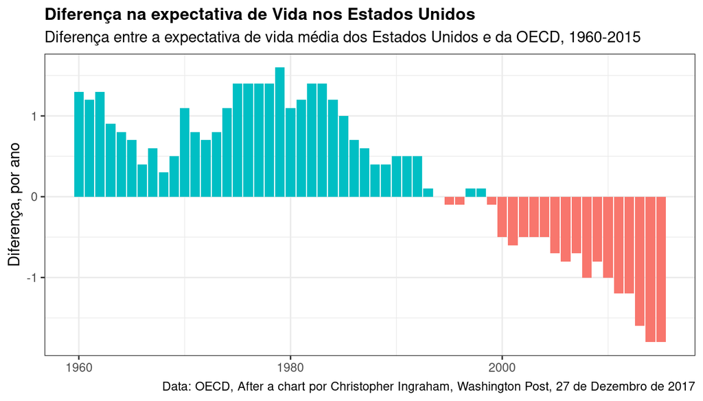

```r
ggplot(data = oecd_sum, mapping = aes(x = year, y = diff, fill = hi_lo)) +
geom_col() +
guides(fill = FALSE) +
labs(x = NULL,
       y = "Diferença, por ano",
       title = "Diferença na expectativa de Vida nos Estados Unidos",
       subtitle = "Diferença entre a expectativa de vida média dos Estados Unidos e da OECD, 1960-2015",
       caption = "Data: OECD, After a chart por Christopher Ingraham, Washington Post, 27 de Dezembro de 2017") +
theme_bw() +
theme(plot.title = element_text(size = 12, face = "bold"))
```

# 3 Gráficos do capítulo 5

Inicialmente, iremos criar um novo **dataframe** a partir do *gss_sm*. Para isso, usamos as funções group_by, summarize e mutate, conforme pede o livro.

```r
rel_by_region <- gss_sm %>%
  group_by(Região, Religião) %>%
  summarize(N = n()) %>%
  mutate(freq = N/sum(N),
         pct = round((freq*100), 0))
```

Com o dataframe **rel_by_region** criado, podemos começar a plotar os gráficos.

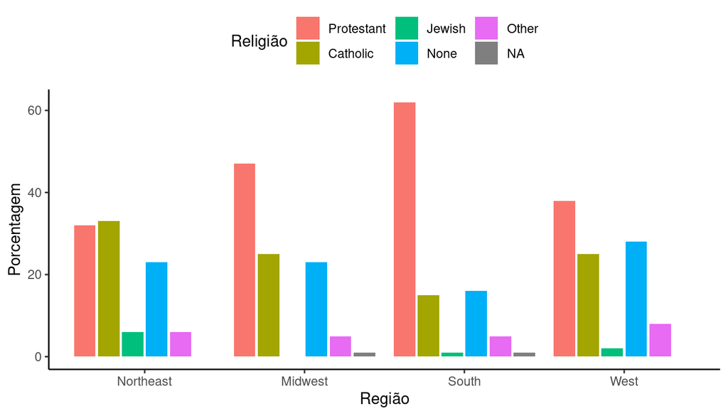

```r
ggplot(rel_by_region, aes(x = Região, y = pct, fill = Religião)) +
geom_col(position = "dodge2") +
labs(y = "Porcentagem")
```

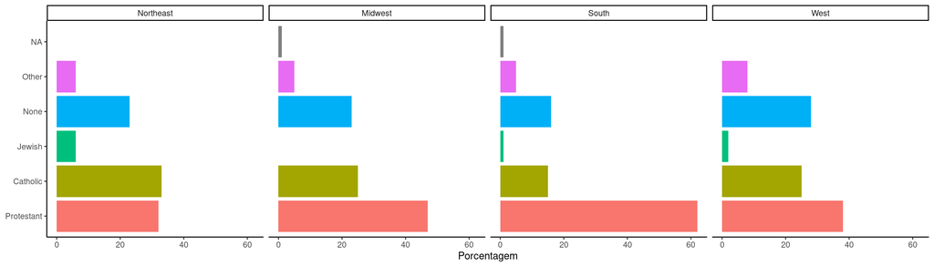

```r
ggplot(rel_by_region, aes(x = Religião, y = pct, fill = Religião)) +
geom_col(position = "dodge2") +
labs(x = NULL, y = "Porcentagem") +
guides(fill = FALSE) +
coord_flip() +
facet_grid(~Região)
```

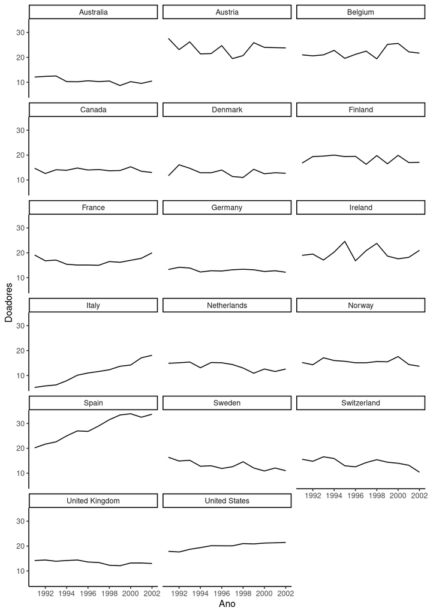

```r
ggplot(organdata, mapping = aes(x = Ano, y = Doadores)) +
geom_line(aes(group = País)) +
facet_wrap(~País, ncol = 3)
```

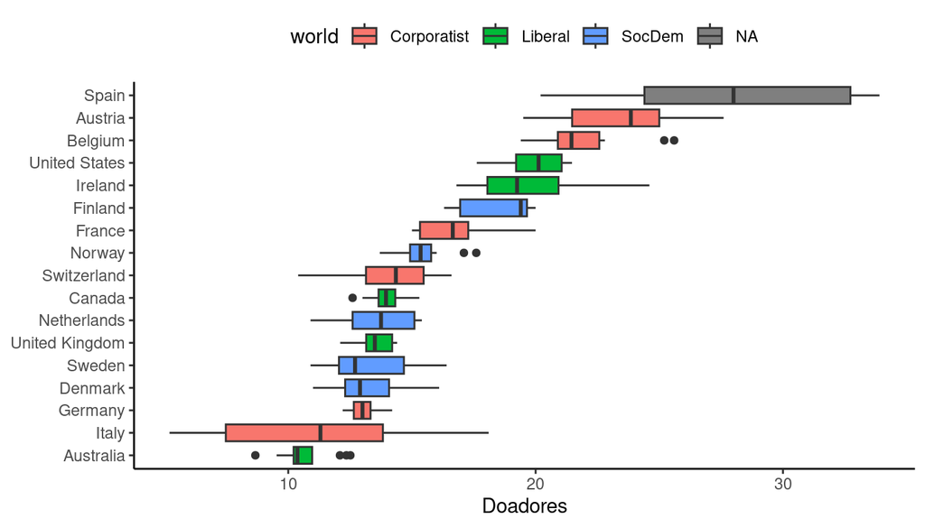

```r
ggplot(organdata, mapping = aes(x = reorder(País, Doadores, na.rm = TRUE), y = Doadores, fill = world)) +
geom_boxplot() +
labs(x = NULL, color = "Mundo") +
coord_flip()
```

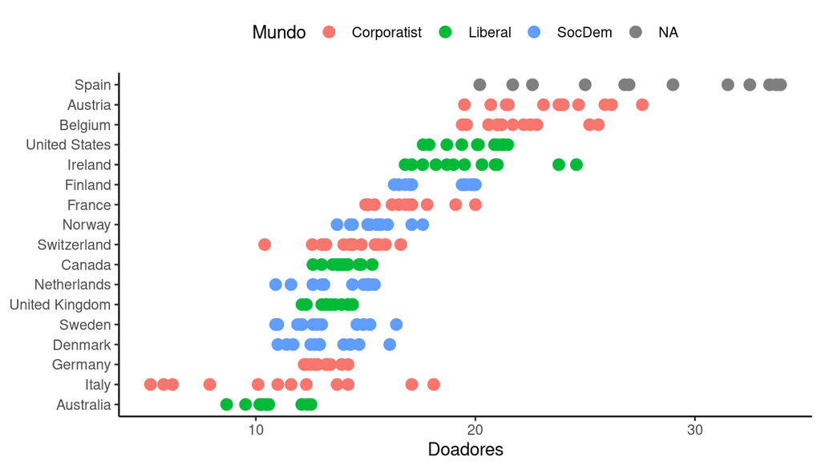

```r
ggplot(organdata, mapping = aes(x = reorder(País, Doadores, na.rm = TRUE), y = Doadores, color = world)) +
geom_point(size = 3) +
labs(x = NULL, color = "Mundo") +
coord_flip()
```

Aqui, criamos outro **dataframe**, dessa vez, a partir do *organdata*.

```r
by_country <- organdata %>% group_by(consent_law, País) %>%
  summarize_if(is.numeric, funs(mean, sd), na.rm = TRUE) %>%
  ungroup
```

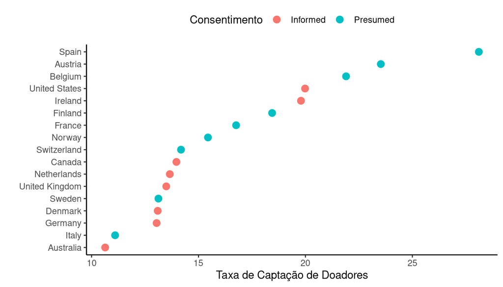

```r
ggplot(by_country, mapping = aes(x = Doadores_mean, y = reorder(País, Doadores_mean), color = consent_law)) +
geom_point(size = 3) +
labs(x = "Taxa de Captação de Doadores", y = "", color = "Consentimento")
```

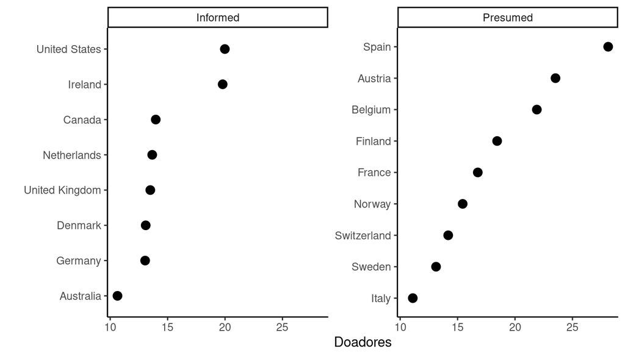

```r
ggplot(by_country, mapping = aes(x = Doadores_mean, y = reorder(País, Doadores_mean))) +
geom_point(size = 3) +
facet_wrap(~consent_law, scales = "free_y", ncol = 2) +
labs(x = "Doadores", y = "")
```

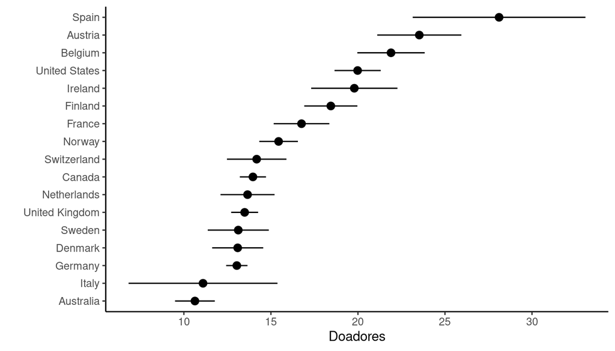

```r
ggplot(by_country, mapping = aes(x = reorder(País, Doadores_mean), y = Doadores_mean)) +
geom_pointrange(mapping = aes(ymin = Doadores_mean - Doadores_sd, ymax = Doadores_mean + Doadores_sd)) +
labs(x = "", y = "Doadores") +
coord_flip() +
theme(legend.position = "none")
```

Aqui, usaremos outro métodos para dar nomes no gráfico. Inicialmente, definimos variáveis com os textos que gostaríamos que aparecessem.

```r
p_title <- "Eleições Presidenciais: margens do colégio eleitoral e Populaçãoular"
p_subtitle <- "1824-2016"
p_caption <- "Os dados de 2016 são provisórios."
x_label <- "Porcentagem de votos Populaçãoulares do vencedor"
y_label <- "Porcentagem de votos dos colégios eleitorais do vencedor"
```

Agora, podemos referenciar as variáveis nos **labs**. Isso é importante, pois assim podemos criar gráficos com legendas alteráveis.

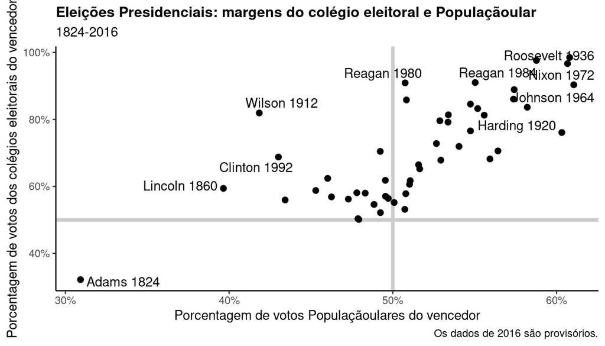

```r
ggplot(elections_historic, aes(x = popular_pct, y = ec_pct, label = winner_label)) +
geom_hline(yintercept = 0.5, size = 1.4, color = "gray80") +
geom_vline(xintercept = 0.5, size = 1.4, color = "gray80") +
geom_point(size =2) +
geom_text_repel(max.overlaps = 5) +
scale_x_continuous(labels = scales::percent) +
scale_y_continuous(labels = scales::percent) +
labs(x = x_label, y = y_label, title = p_title, subtitle = p_subtitle, caption = p_caption)
```

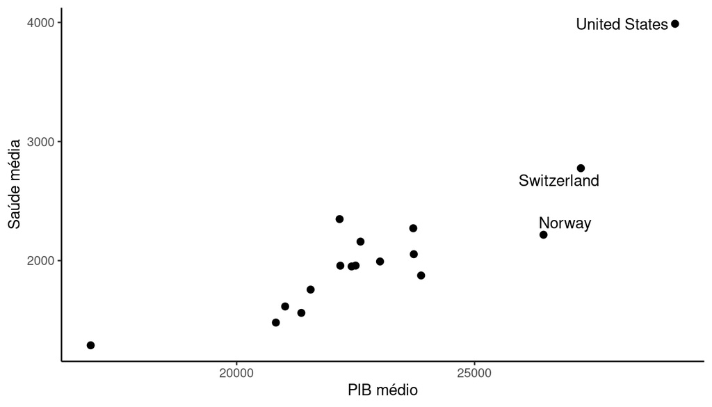

```r
ggplot(by_country, mapping = aes(x = gdp_mean, y = health_mean)) +
geom_point(size =2) +
geom_text_repel(data = subset(by_country, gdp_mean > 25000), mapping = aes(label = País)) +
labs(x = "PIB médio", y = "Saúde média")
```